```python
import pandas as pd
pd.set_option('display.expand_frame_repr', False)

import matplotlib
import matplotlib.pyplot as plt
font = {'size' : 20}
matplotlib.rc('font', **font)

from pylab import rcParams
rcParams["figure.figsize"] = 30,16

import seaborn as sns

from statsmodels.tsa.statespace.sarimax import SARIMAX
from pmdarima.arima import auto_arima

import datetime as dt
from datetime import timedelta, date

from sklearn.preprocessing import MinMaxScaler
import joblib

import warnings
warnings.filterwarnings("ignore")

import sys
sys.path.insert(0, "../")
import functions
```

```python
#Unskalierte Daten für Analysen laden
df_unscaled = pd.read_csv("../3-Data Preparation/data.csv", index_col=0, parse_dates=True)
df_unscaled.index.freq = "D"

#Wahre Werte der Testdaten
y_true = df_unscaled["verbrauch"]["2021-01-01":]

#Skalierte Daten für Modellierung laden
df_scaled = pd.read_csv("../3-Data Preparation/data_scaled.csv", index_col=0, parse_dates=True)
df_scaled.index.freq = "D"

#Aufteilung in endogene und exogene Daten
exog_train = df_scaled[["arbeitstag", "temperatur"]][:"2020-12-31"]
exog_test = df_scaled[["arbeitstag", "temperatur"]]["2021-01-01":]

exog = exog_train.append(exog_test)

endog_train = df_scaled["verbrauch"][:"2020-12-31"]
endog_test = df_scaled["verbrauch"]["2021-01-01":]

endog = endog_train.append(endog_test)
```

# Verbesserung durch Urlaubssaison

Das ARIMA(2,0,2)(2,0,2) [Arbeitstag, Temperatur] erstellt vor allem um Weihnachten herum sehr schlechte Prognosen und hat daher in diesem Bereich große Abweichungen. Es wird daher ein Indikator für die Urlaubssaison hinzugefügt. Der Indikator wird während der Urlaubssaison auf 1 und ansonsten auf 0 gesetzt. Als „lange“ Urlaubssaison wird jeweils der Zeitraum in der Woche vor und nach Weihnachten sowie die erste Januarwoche bezeichnet. Falls das Modell durch diesen Indikator nicht verbessert wird, wird stattdessen die „kurze“ Urlaubssaison verwendet, die nur die jeweiligen Tage vor und nach den Weihnachtsfeiertagen fasst. Die Daten für die Urlaubssaison werden manuell ermittelt. Sie wurden jeweils in den Dateien „urlaubssaison_1“ für die lange und „urlaubssaison_2“ für die kurze Urlaubssaison im Ordner „Daten“ gespeichert.

## ARIMA(2,0,2)(2,0,2)7 [Arbeitstag, Temperatur, Urlaubssaison] (lange Urlaubssaison)

Die lange Urlaubssaison verbessert das Modell so gut wie gar nicht. Der MAPE steigt auf 2,24% an, die Log-Likelihood fällt leicht auf 4.340, dementsprechend steigt das AIC auf -8.656 an. Das Modell kann also keine Informationen aus den Daten generalisieren. Die Vorhersagen im Zeitraum der Urlaubssaison sind weiterhin sehr schecht.

```python
#Skalierte Daten für Modellierung laden
df_scaled = pd.read_csv("../3-Data Preparation/data_scaled.csv", index_col=0, parse_dates=True)
df_scaled.index.freq = "D"

#Exogene Daten um Urlaubssaison erweitern
df_scaled["urlaubssaison"] = pd.read_csv("Daten/urlaubssaison_1.csv", index_col=0, parse_dates=True)

#Aufteilung in endogene und exogene Daten
exog_train = df_scaled[["arbeitstag","temperatur","urlaubssaison"]][:"2020-12-31"]
exog_test = df_scaled[["arbeitstag","temperatur","urlaubssaison"]]["2021-01-01":]

exog = exog_train.append(exog_test)
```

```python
#Nicht-saisonale und saisonale Ordnung festlegen
order = (2, 0, 2) #p, d, q
seasonal_order = (2, 0, 2, 7) #P, D, Q, m

#Modell mit Trainingsdaten erstellen
train_model_config = SARIMAX(endog=endog_train, exog=exog_train, order=order, seasonal_order=seasonal_order)
train_model = train_model_config.fit()

#Modell mit allen Daten erstllen und Konfiguration/Koeffizienten von ersten Modell übernehmen (kein neues Training)
model_config = SARIMAX(endog=endog, exog=exog, order=order, seasonal_order=seasonal_order)
model = model_config.filter(train_model.params)

#Modell ausgeben
print(model.summary())
print()
```

```
                                     SARIMAX Results
=========================================================================================
Dep. Variable:                         verbrauch   No. Observations:                 2557
Model:             SARIMAX(2, 0, 2)x(2, 0, 2, 7)   Log Likelihood                4340.003
Date:                           Thu, 03 Feb 2022   AIC                          -8656.006
Time:                                   15:28:51   BIC                          -8585.846
Sample:                               01-01-2015   HQIC                         -8630.564
                                    - 12-31-2021
Covariance Type:                             opg
=================================================================================
                    coef    std err          z      P>|z|      [0.025      0.975]
---------------------------------------------------------------------------------
arbeitstag        0.2915      0.002    123.528      0.000       0.287       0.296
temperatur       -0.0400      0.014     -2.804      0.005      -0.068      -0.012
urlaubssaison    -0.0393      0.008     -5.150      0.000      -0.054      -0.024
ar.L1             1.0591      0.153      6.915      0.000       0.759       1.359
ar.L2            -0.1303      0.136     -0.958      0.338      -0.397       0.136
ma.L1            -0.2595      0.154     -1.688      0.091      -0.561       0.042
ma.L2            -0.0708      0.022     -3.155      0.002      -0.115      -0.027
ar.S.L7           0.1733      0.047      3.650      0.000       0.080       0.266
ar.S.L14          0.8182      0.047     17.443      0.000       0.726       0.910
ma.S.L7           0.0202      0.043      0.469      0.639      -0.064       0.105
ma.S.L14         -0.7660      0.032    -24.220      0.000      -0.828      -0.704
sigma2            0.0020   2.89e-05     69.779      0.000       0.002       0.002
===================================================================================
Ljung-Box (L1) (Q):                   4.97   Jarque-Bera (JB):              8633.31
Prob(Q):                              0.03   Prob(JB):                         0.00
Heteroskedasticity (H):               1.11   Skew:                            -0.90
Prob(H) (two-sided):                  0.13   Kurtosis:                        11.82
===================================================================================

Warnings:
[1] Covariance matrix calculated using the outer product of gradients (complex-step).
```

```
      Vorhersage
R2          0.95
MAE       3813.0
MSE   31445855.0
RMSE      5608.0

MAPE      2.24 %
```

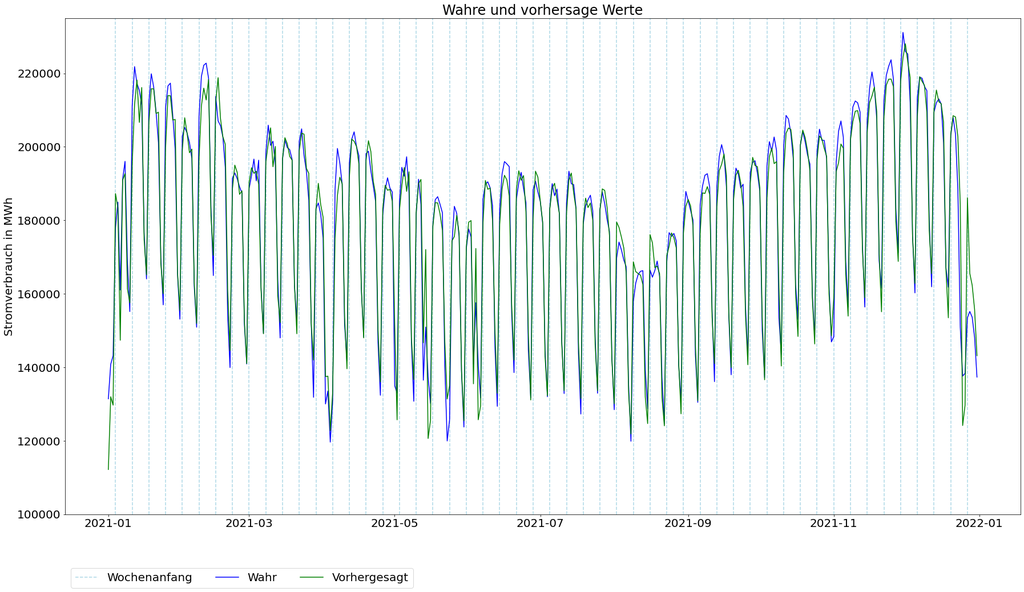

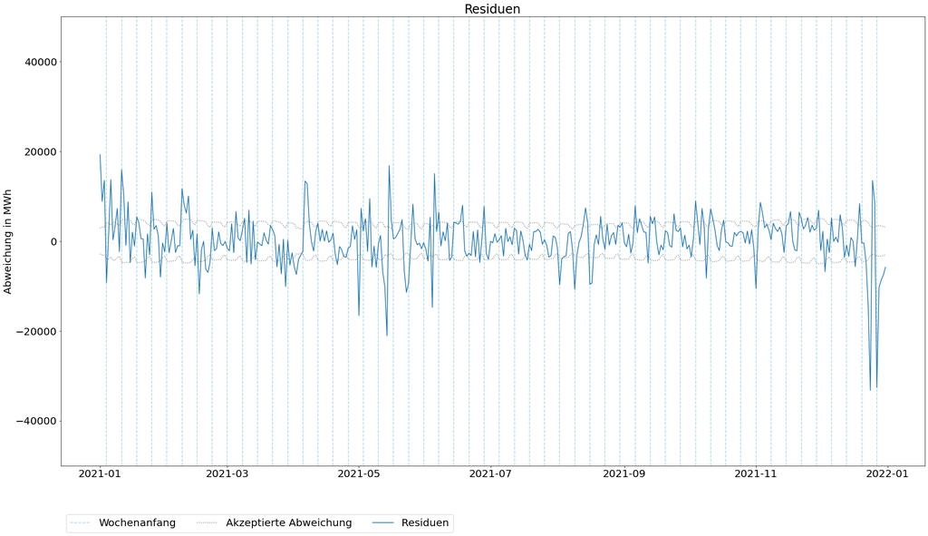

```python
#Vorhersage erzeugen
scaled_preds = model.predict(start="2021-01-01", end="2021-12-31", dynamic=False).values

#Vorhersagen mit echten Werten vergleichen
functions.custom_metrics_arima(y_true, scaled_preds, residuals=True)
```

## ARIMA(2,0,2)(2,0,2)7 [Arbeitstag, Temperatur, Urlaubssaison] (kurze Urlaubssaison)

Es zeigt sich praktisch kein Unterschied zwischen der langen und der kurzen Urlaubssaison. MAPE, Log-Likelihood und AIC sind praktisch gleich. Eine Verbesserung kann nicht erzielt werden.

```python
#Skalierte Daten für Modellierung laden
df_scaled = pd.read_csv("../3-Data Preparation/data_scaled.csv", index_col=0, parse_dates=True)
df_scaled.index.freq = "D"

#Exogene Daten um Urlaubssaison erweitern
df_scaled["urlaubssaison"] = pd.read_csv("Daten/urlaubssaison_2.csv", index_col=0, parse_dates=True)

#Aufteilung in endogene und exogene Daten
exog_train = df_scaled[["arbeitstag","temperatur","urlaubssaison"]][:"2020-12-31"]
exog_test = df_scaled[["arbeitstag","temperatur","urlaubssaison"]]["2021-01-01":]

exog = exog_train.append(exog_test)
```

```python
#Nicht-saisonale und saisonale Ordnung festlegen
order = (2, 0, 2) #p, d, q
seasonal_order = (2, 0, 2, 7) #P, D, Q, m

#Modell mit Trainingsdaten erstellen
train_model_config = SARIMAX(endog=endog_train, exog=exog_train, order=order, seasonal_order=seasonal_order)
train_model = train_model_config.fit()

#Modell mit allen Daten erstllen und Konfiguration/Koeffizienten von ersten Modell übernehmen (kein neues Training)
model_config = SARIMAX(endog=endog, exog=exog, order=order, seasonal_order=seasonal_order)
model = model_config.filter(train_model.params)

#Modell ausgeben
print(model.summary())
print()
```

```
                                     SARIMAX Results
=========================================================================================
Dep. Variable:                         verbrauch   No. Observations:                 2557
Model:             SARIMAX(2, 0, 2)x(2, 0, 2, 7)   Log Likelihood                4334.148
Date:                           Thu, 03 Feb 2022   AIC                          -8644.297
Time:                                   15:29:01   BIC                          -8574.138
Sample:                               01-01-2015   HQIC                         -8618.855
                                    - 12-31-2021
Covariance Type:                             opg
=================================================================================
                    coef    std err          z      P>|z|      [0.025      0.975]
---------------------------------------------------------------------------------
arbeitstag        0.2948      0.002    129.998      0.000       0.290       0.299
temperatur       -0.0326      0.014     -2.395      0.017      -0.059      -0.006
urlaubssaison    -0.0667      0.008     -8.621      0.000      -0.082      -0.052
ar.L1             1.0422      0.109      9.525      0.000       0.828       1.257
ar.L2            -0.1065      0.097     -1.098      0.272      -0.297       0.084
ma.L1            -0.2257      0.110     -2.059      0.039      -0.441      -0.011
ma.L2            -0.1138      0.018     -6.429      0.000      -0.148      -0.079
ar.S.L7           0.2138      0.053      4.012      0.000       0.109       0.318
ar.S.L14          0.7759      0.053     14.713      0.000       0.673       0.879
ma.S.L7           0.0714      0.050      1.440      0.150      -0.026       0.169
ma.S.L14         -0.6694      0.032    -20.815      0.000      -0.732      -0.606
sigma2            0.0020   2.94e-05     66.506      0.000       0.002       0.002
===================================================================================
Ljung-Box (L1) (Q):                   0.06   Jarque-Bera (JB):              5846.39
Prob(Q):                              0.80   Prob(JB):                         0.00
Heteroskedasticity (H):               1.12   Skew:                            -0.66
Prob(H) (two-sided):                  0.09   Kurtosis:                        10.29
===================================================================================

Warnings:
[1] Covariance matrix calculated using the outer product of gradients (complex-step).
```

```
      Vorhersage
R2          0.96
MAE       3827.0
MSE   31118125.0
RMSE      5578.0

MAPE      2.24 %
```

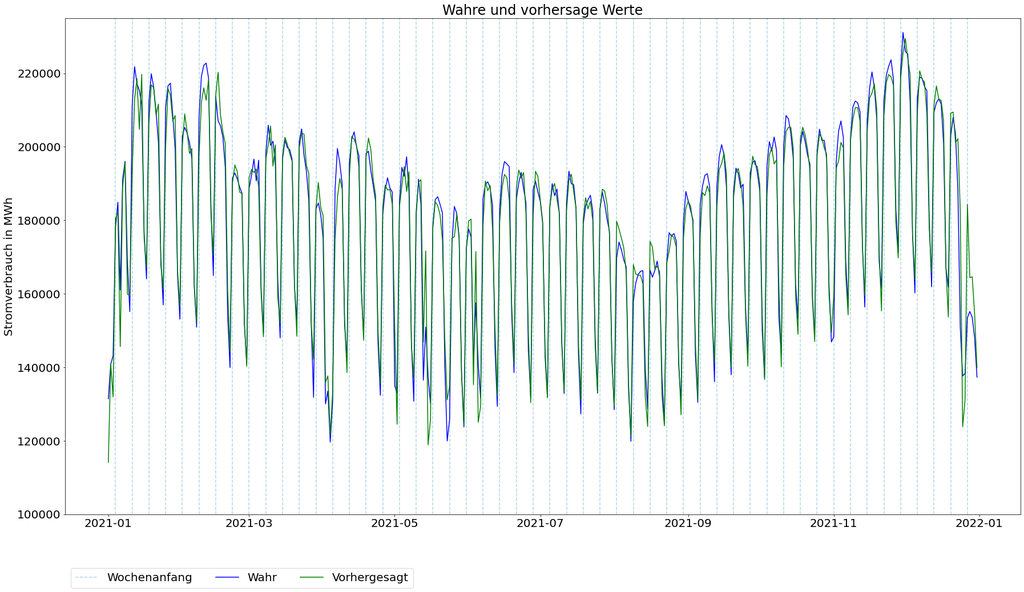

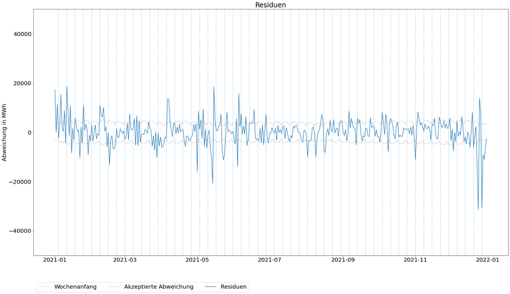

```python
#Vorhersage erzeugen
scaled_preds = model.predict(start="2021-01-01", end="2021-12-31", dynamic=False).values

#Vorhersagen mit echten Werten vergleichen
functions.custom_metrics_arima(y_true, scaled_preds, residuals=True)
```

# Verbesserung durch Erweiterung der arbeitsfreien Tage

Mit gerade einmal 70 Datensätzen gibt es relativ wenig Daten für die Urlaubssaison. Auf Oversampling wird aus den in der Arbeit genannten Gründen verzichtet. Stattdessen wird allerdings versucht, die Urlaubssaison und den Indikator für Arbeitstage zusammenzulegen. Dadurch wird kein zusätzliches Merkmal benötigt, allerdings kann der niedrigere Stromverbrauch in der Urlaubssaison dadurch möglicherweise besser abgebildet werden. Dafür wird der Indikator für Arbeitstage bei allen Datensätzen, die in die Urlaubssaison fallen, auf 0 gesetzt.

## ARIMA(2,0,2)(2,0,2)7 [Arbeitstag, Temperatur] (lange Urlaubssaison -> arbeitsfreie Tage)

Wenn die lange Urlaubssaison mit dem Indikator für Arbeitstage zusammengelegt wird, dann führt dies zu einer signifikanten Verbesserung im entsprechenden Zeitraum. Der MAPE erreicht 2,09% und schlägt damit die Baseline sowie das Erfolgskriterium. Die Log-Likelihood steigt auf 4.360 an, das AIC fällt auf -8.698 ab. Das Modell hat sich also ohne überanzupassen sichtlich verbessert.

```python
#Skalierte Daten für Modellierung laden
df_scaled = pd.read_csv("../3-Data Preparation/data_scaled.csv", index_col=0, parse_dates=True)
df_scaled.index.freq = "D"

#Arbeitsfreie Tage erweitern
df_scaled["urlaubssaison"] = pd.read_csv("Daten/urlaubssaison_1.csv", index_col=0, parse_dates=True)
df_scaled.loc[df_scaled["urlaubssaison"] == 1, 'arbeitstag'] = 0

#Aufteilung in endogene und exogene Daten
exog_train = df_scaled[["arbeitstag","temperatur"]][:"2020-12-31"]
exog_test = df_scaled[["arbeitstag","temperatur"]]["2021-01-01":]

exog = exog_train.append(exog_test)
```

```python
#Nicht-saisonale und saisonale Ordnung festlegen
order = (2, 0, 2) #p, d, q
seasonal_order = (2, 0, 2, 7) #P, D, Q, m

#Modell mit Trainingsdaten erstellen
train_model_config = SARIMAX(endog=endog_train, exog=exog_train, order=order, seasonal_order=seasonal_order)
train_model = train_model_config.fit()

#Modell mit allen Daten erstllen und Konfiguration/Koeffizienten von ersten Modell übernehmen (kein neues Training)
model_config = SARIMAX(endog=endog, exog=exog, order=order, seasonal_order=seasonal_order)
model = model_config.filter(train_model.params)

#Modell ausgeben
print(model.summary())
print()
```

```
                                     SARIMAX Results
=========================================================================================
Dep. Variable:                         verbrauch   No. Observations:                 2557
Model:             SARIMAX(2, 0, 2)x(2, 0, 2, 7)   Log Likelihood                4359.965
Date:                           Thu, 03 Feb 2022   AIC                          -8697.929
Time:                                   15:29:11   BIC                          -8633.617
Sample:                               01-01-2015   HQIC                         -8674.608
                                    - 12-31-2021
Covariance Type:                             opg
==============================================================================
                 coef    std err          z      P>|z|      [0.025      0.975]
------------------------------------------------------------------------------
arbeitstag     0.2888      0.002    137.791      0.000       0.285       0.293
temperatur    -0.0779      0.015     -5.249      0.000      -0.107      -0.049
ar.L1          0.8465      0.275      3.078      0.002       0.308       1.385
ar.L2          0.0481      0.251      0.191      0.848      -0.444       0.541
ma.L1          0.1300      0.276      0.470      0.638      -0.412       0.672
ma.L2          0.0631      0.023      2.709      0.007       0.017       0.109
ar.S.L7        0.2290      0.087      2.619      0.009       0.058       0.400
ar.S.L14       0.7555      0.087      8.728      0.000       0.586       0.925
ma.S.L7       -0.0488      0.080     -0.609      0.543      -0.206       0.108
ma.S.L14      -0.7025      0.066    -10.717      0.000      -0.831      -0.574
sigma2         0.0020   3.26e-05     62.452      0.000       0.002       0.002
===================================================================================
Ljung-Box (L1) (Q):                   5.35   Jarque-Bera (JB):              7581.45
Prob(Q):                              0.02   Prob(JB):                         0.00
Heteroskedasticity (H):               0.85   Skew:                             0.24
Prob(H) (two-sided):                  0.02   Kurtosis:                        11.42
===================================================================================

Warnings:
[1] Covariance matrix calculated using the outer product of gradients (complex-step).
```

```
      Vorhersage
R2          0.96
MAE       3515.0
MSE   26532417.0
RMSE      5151.0

MAPE      2.09 %
```

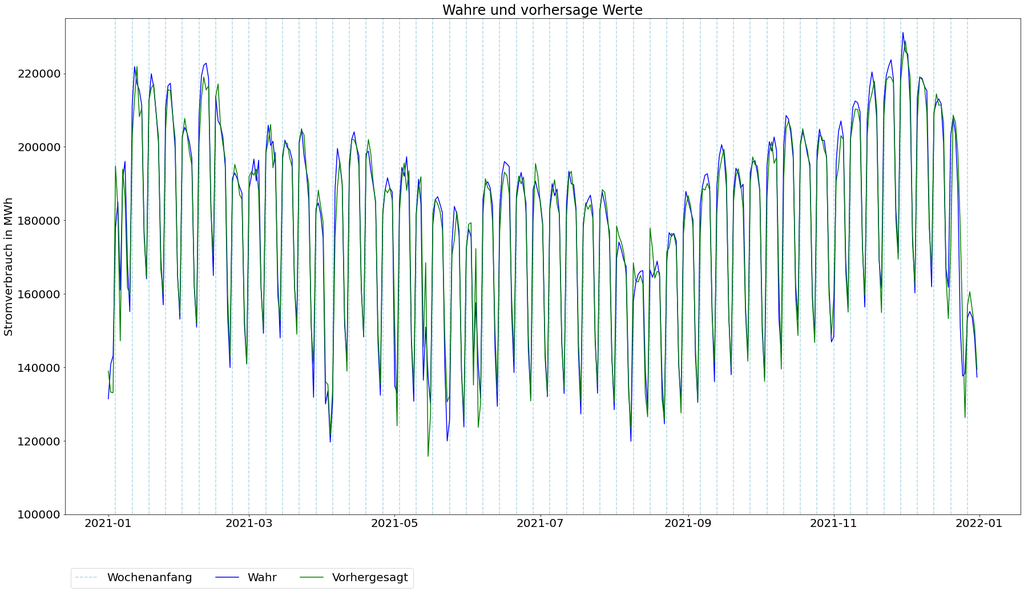

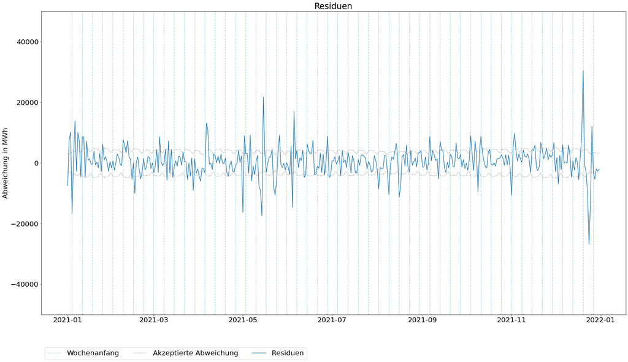

```python
#Vorhersage erzeugen
scaled_preds = model.predict(start="2021-01-01", end="2021-12-31", dynamic=False).values

#Vorhersagen mit echten Werten vergleichen
functions.custom_metrics_arima(y_true, scaled_preds, residuals=True)
```

## ARIMA(2,0,2)(2,0,2)7 [Arbeitstag, Temperatur] (kurze Urlaubssaison -> arbeitsfreie Tage)

Wenn die kurze Urlaubssaison mit dem Indikator für Arbeitstage zusammengelegt wird, dann führt dies zu einer etwas schwächeren Verbesserung im entsprechenden Zeitraum. Der MAPE erreicht 2,1%, schlägt damit aber immer noch die Baseline sowie das Erfolgskriterium. Die Log-Likelihood steigt auf 4.557 an, das AIC fällt auf -9.092 ab. Das Modell hat sich also ohne überanzupassen sichtlich verbessert. Der MAPE ist zwar etwas schlechter als bei der langen Urlaubssaison, da Log-Likelihood und AIC jedoch sehr viel besser sind, wird die kurze Urlaubssaison im weiteren Verlauf mit dem Indikator für Arbeitstage zusammengelegt.

```python
#Skalierte Daten für Modellierung laden
df_scaled = pd.read_csv("../3-Data Preparation/data_scaled.csv", index_col=0, parse_dates=True)
df_scaled.index.freq = "D"

#Arbeitsfreie Tage erweitern
df_scaled["urlaubssaison"] = pd.read_csv("Daten/urlaubssaison_2.csv", index_col=0, parse_dates=True)
df_scaled.loc[df_scaled["urlaubssaison"] == 1, 'arbeitstag'] = 0

#Aufteilung in endogene und exogene Daten
exog_train = df_scaled[["arbeitstag","temperatur"]][:"2020-12-31"]
exog_test = df_scaled[["arbeitstag","temperatur"]]["2021-01-01":]

exog = exog_train.append(exog_test)
```

```python
#Nicht-saisonale und saisonale Ordnung festlegen
order = (2, 0, 2) #p, d, q
seasonal_order = (2, 0, 2, 7) #P, D, Q, m

#Modell mit Trainingsdaten erstellen
train_model_config = SARIMAX(endog=endog_train, exog=exog_train, order=order, seasonal_order=seasonal_order)
train_model = train_model_config.fit()

#Modell mit allen Daten erstllen und Konfiguration/Koeffizienten von ersten Modell übernehmen (kein neues Training)
model_config = SARIMAX(endog=endog, exog=exog, order=order, seasonal_order=seasonal_order)
model = model_config.filter(train_model.params)

#Modell ausgeben
print(model.summary())
print()
```

```
                                     SARIMAX Results
=========================================================================================
Dep. Variable:                         verbrauch   No. Observations:                 2557
Model:             SARIMAX(2, 0, 2)x(2, 0, 2, 7)   Log Likelihood                4556.901
Date:                           Thu, 03 Feb 2022   AIC                          -9091.801
Time:                                   15:29:20   BIC                          -9027.489
Sample:                               01-01-2015   HQIC                         -9068.479
                                    - 12-31-2021
Covariance Type:                             opg
==============================================================================
                 coef    std err          z      P>|z|      [0.025      0.975]
------------------------------------------------------------------------------
arbeitstag     0.2951      0.002    151.520      0.000       0.291       0.299
temperatur    -0.0734      0.014     -5.418      0.000      -0.100      -0.047
ar.L1          1.1178      0.102     10.921      0.000       0.917       1.318
ar.L2         -0.1766      0.091     -1.950      0.051      -0.354       0.001
ma.L1         -0.2569      0.103     -2.486      0.013      -0.459      -0.054
ma.L2         -0.1455      0.015     -9.447      0.000      -0.176      -0.115
ar.S.L7        0.1746      0.638      0.274      0.784      -1.076       1.425
ar.S.L14       0.8174      0.635      1.287      0.198      -0.428       2.062
ma.S.L7       -0.0991      0.631     -0.157      0.875      -1.335       1.137
ma.S.L14      -0.7655      0.581     -1.317      0.188      -1.905       0.374
sigma2         0.0017   2.85e-05     59.953      0.000       0.002       0.002
===================================================================================
Ljung-Box (L1) (Q):                   0.03   Jarque-Bera (JB):              3671.53
Prob(Q):                              0.85   Prob(JB):                         0.00
Heteroskedasticity (H):               0.91   Skew:                            -0.16
Prob(H) (two-sided):                  0.17   Kurtosis:                         8.86
===================================================================================

Warnings:
[1] Covariance matrix calculated using the outer product of gradients (complex-step).
```

```
      Vorhersage
R2          0.96
MAE       3613.0
MSE   26901261.0
RMSE      5187.0

MAPE       2.1 %
```

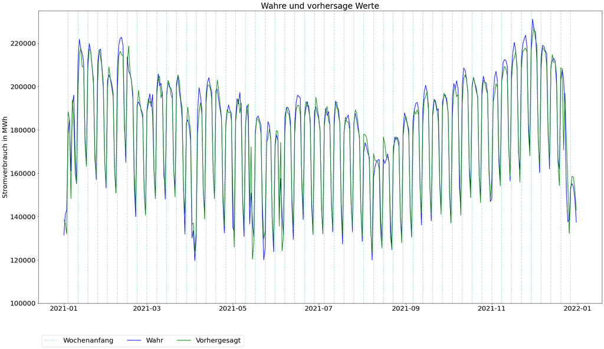

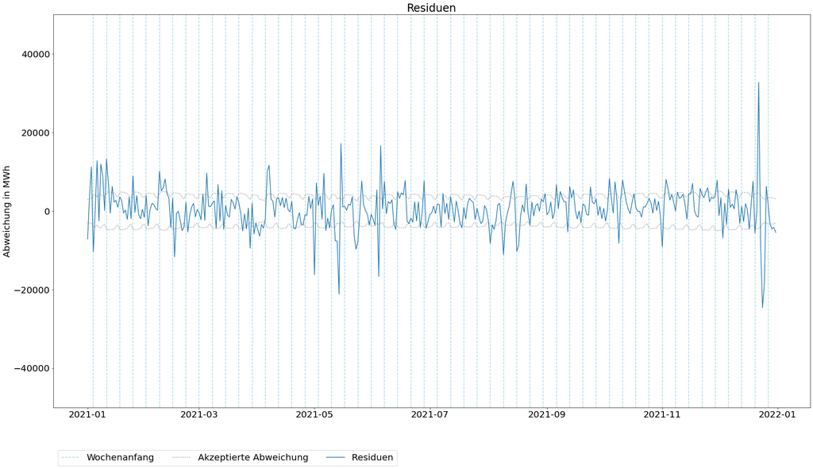

```python
#Vorhersage erzeugen
scaled_preds = model.predict(start="2021-01-01", end="2021-12-31", dynamic=False).values

#Vorhersagen mit echten Werten vergleichen
functions.custom_metrics_arima(y_true, scaled_preds, residuals=True)
```

# Ergebnis

Durch die Modifikation des Indikators für Arbeitstage währen der (kurzen) Urlaubssaison um die Weihnachtsfeiertage verbessert sich das Modell auf einen MAPE von 2,10%. Die Baseline und das Erfolgskriterium werden damit geschlagen. Es gibt daher einen Rücksprung in die Phase der Data Preparation. Die modifizierten Arbeitstage werden in den Daten persistiert. Das weitere Modeling wird also mit den in der Datei „arima_data_scaled.csv“ gespeicherten Daten durchgeführt.

## ARIMA(2,0,2)(2,0,2)7 [Arbeitstag, Temperatur]

Das neue ARIMA(2,0,2)(2,0,2)7 [Arbeitstag, Temperatur] bildet die Zeitreihe etwas besser ab. Auf das ganze Jahr gesehen sind die Änderungen zwar gering, allerdings verbessert sich das Modell um die Weihnachtsfeiertage sichtbar. An den Weihnachtsfeiertagen und Feiertagen gibt es allerdings immer noch starke Abweichungen.

```python
#Unskalierte Daten für Analysen laden
df_unscaled = pd.read_csv("../3-Data Preparation/arima_data_unscaled.csv", index_col=0, parse_dates=True)
df_unscaled.index.freq = "D"

#Wahre Werte der Testdaten
y_true = df_unscaled["verbrauch"]["2021-01-01":]

#Skalierte Daten für Modellierung laden
df_scaled = pd.read_csv("../3-Data Preparation/arima_data_scaled.csv", index_col=0, parse_dates=True)
df_scaled.index.freq = "D"

#Aufteilung in endogene und exogene Daten
exog_train = df_scaled[["arbeitstag", "temperatur"]][:"2020-12-31"]
exog_test = df_scaled[["arbeitstag", "temperatur"]]["2021-01-01":]

exog = exog_train.append(exog_test)

endog_train = df_scaled["verbrauch"][:"2020-12-31"]
endog_test = df_scaled["verbrauch"]["2021-01-01":]

endog = endog_train.append(endog_test)
```

```python
#Nicht-saisonale und saisonale Ordnung festlegen
order = (2, 0, 2) #p, d, q
seasonal_order = (2, 0, 2, 7) #P, D, Q, m

#Modell mit Trainingsdaten erstellen
train_model_config = SARIMAX(endog=endog_train, exog=exog_train, order=order, seasonal_order=seasonal_order)
train_model = train_model_config.fit()

#Modell mit allen Daten erstllen und Konfiguration/Koeffizienten von ersten Modell übernehmen (kein neues Training)
model_config = SARIMAX(endog=endog, exog=exog, order=order, seasonal_order=seasonal_order)
model = model_config.filter(train_model.params)

#Modell ausgeben
print(model.summary())
print()
```

```
                                     SARIMAX Results
=========================================================================================
Dep. Variable:                         verbrauch   No. Observations:                 2557
Model:             SARIMAX(2, 0, 2)x(2, 0, 2, 7)   Log Likelihood                4556.901
Date:                           Thu, 03 Feb 2022   AIC                          -9091.801
Time:                                   15:37:13   BIC                          -9027.489
Sample:                               01-01-2015   HQIC                         -9068.479
                                    - 12-31-2021
Covariance Type:                             opg
==============================================================================
                 coef    std err          z      P>|z|      [0.025      0.975]
------------------------------------------------------------------------------
arbeitstag     0.2951      0.002    151.520      0.000       0.291       0.299
temperatur    -0.0734      0.014     -5.418      0.000      -0.100      -0.047
ar.L1          1.1178      0.102     10.921      0.000       0.917       1.318
ar.L2         -0.1766      0.091     -1.950      0.051      -0.354       0.001
ma.L1         -0.2569      0.103     -2.486      0.013      -0.459      -0.054
ma.L2         -0.1455      0.015     -9.447      0.000      -0.176      -0.115
ar.S.L7        0.1746      0.638      0.274      0.784      -1.076       1.425
ar.S.L14       0.8174      0.635      1.287      0.198      -0.428       2.062
ma.S.L7       -0.0991      0.631     -0.157      0.875      -1.335       1.137
ma.S.L14      -0.7655      0.581     -1.317      0.188      -1.905       0.374
sigma2         0.0017   2.85e-05     59.953      0.000       0.002       0.002
===================================================================================
Ljung-Box (L1) (Q):                   0.03   Jarque-Bera (JB):              3671.53
Prob(Q):                              0.85   Prob(JB):                         0.00
Heteroskedasticity (H):               0.91   Skew:                            -0.16
Prob(H) (two-sided):                  0.17   Kurtosis:                         8.86
===================================================================================

Warnings:
[1] Covariance matrix calculated using the outer product of gradients (complex-step).
```

```
      Vorhersage
R2          0.96
MAE       3613.0
MSE   26901261.0
RMSE      5187.0

MAPE       2.1 %
```

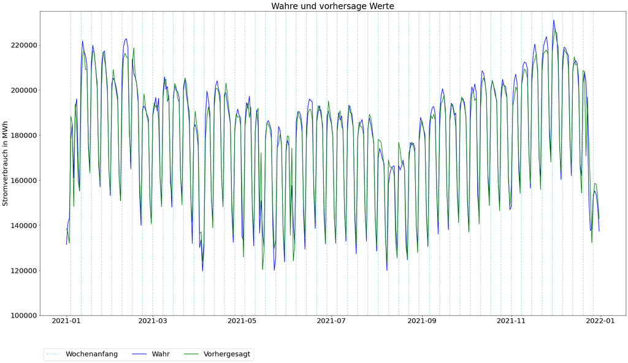

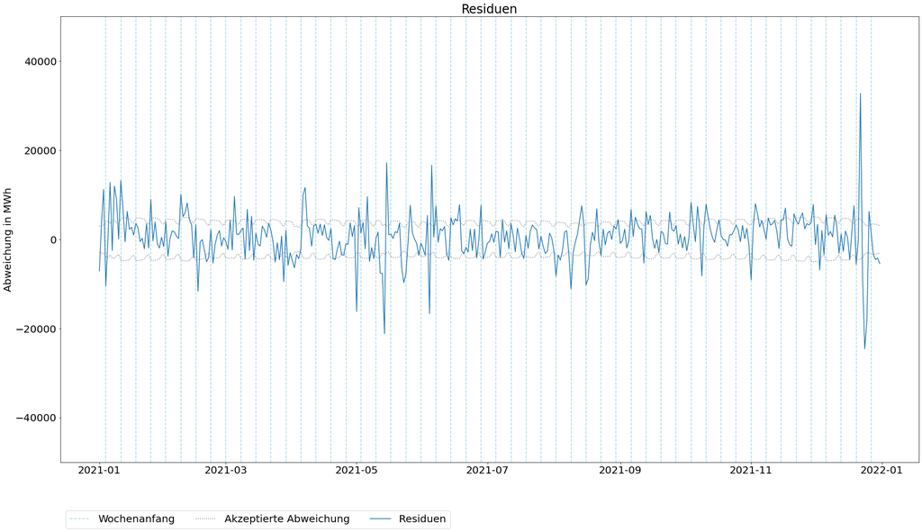

```python
#Vorhersage erzeugen
scaled_preds = model.predict(start="2021-01-01", end="2021-12-31", dynamic=False).values

#Vorhersagen mit echten Werten vergleichen
functions.custom_metrics_arima(y_true, scaled_preds, residuals=True)
```